# An Analytical Detective

Mohammed Ali

June 30, 2018

# An analytical detective

Crime is an international concern, but it is documented and handled in very different ways in different countries. In the United States, violent crimes and property crimes are recorded by the Federal Bureau of Investigation (FBI). Additionally, each city documents crime, and some cities release data regarding crime rates. The city of Chicago, Illinois releases crime data from 2001 onward

Read the dataset mvtWeek1.csv into R, using the read.csv function, and call the data frame ‘mvt’. Remember to navigate to the directory on your computer containing the file mvtWeek1.csv first. It may take a few minutes to read in the data, since it is pretty large. Then, use the str and summary functions to answer the following questions.

## Loading the Data

```r
mvt <- read.csv("data/mvtWeek1.csv")
```

How many rows of data (observations) are in this dataset?

```r
nrow(mvt)
```

```
## [1] 191641
```

How many variables are in this dataset?

```r
ncol(mvt)
```

```
## [1] 11
```

Using the “max” function, what is the maximum value of the variable “ID”?

```r
max(mvt$ID)
```

```
## [1] 9181151
```

What is the minimum value of the variable “Beat”?

```r
min(mvt$Beat)
```

```
## [1] 111
```

How many observations have value TRUE in the Arrest variable (this is the number of crimes for which an arrest was made)?

```r
table(mvt$Arrest)
```

```
##
##  FALSE   TRUE
## 176105  15536
```

How many observations have a LocationDescription value of ALLEY?

```r
table(mvt$LocationDescription == "ALLEY")
```

```
##
##  FALSE   TRUE
## 189333   2308
```

## Understanding Dates in R

In many datasets, like this one, you have a date field. Unfortunately, R does not automatically recognize entries that look like dates. We need to use a function in R to extract the date and time. Take a look at the first entry of Date (remember to use square brackets when looking at a certain entry of a variable).

In what format are the entries in the variable Date?

```r
mvt$Date[1]
```

```
## [1] 12/31/12 23:15
## 131680 Levels: 1/1/01 0:01 1/1/01 0:05 1/1/01 0:30 1/1/01 1:17 ... 9/9/12 9:50
```

Now, let’s convert these characters into a Date object in R. In your R console, type

`DateConvert = as.Date(strptime(mvt$Date, "%m/%d/%y %H:%M"))`

This converts the variable “Date” into a Date object in R. Take a look at the variable DateConvert using the summary function.

What is the month and year of the median date in our dataset? Enter your answer as “Month Year”, without the quotes. (Ex: if the answer was 2008-03-28, you would give the answer “March 2008”, without the quotes.)

```r
DateConvert = as.Date(strptime(mvt$Date, "%m/%d/%y %H:%M"))
summary(DateConvert)
```

```
##         Min.      1st Qu.       Median         Mean      3rd Qu.
## "2001-01-01" "2003-07-10" "2006-05-21" "2006-08-23" "2009-10-24"
##         Max.
## "2012-12-31"
```

Now, let’s extract the month and the day of the week, and add these variables to our data frame mvt. We can do this with two simple functions. Type the following commands in R:

`mvt$Month = months(DateConvert)`

`mvt$Weekday = weekdays(DateConvert)`

This creates two new variables in our data frame, Month and Weekday, and sets them equal to the month and weekday values that we can extract from the Date object. Lastly, replace the old Date variable with DateConvert by typing:

`mvt$Date = DateConvert`

Using the table command, answer the following questions.

In which month did the fewest motor vehicle thefts occur?

```r
mvt$Month = months(DateConvert)
mvt$Weekday = weekdays(DateConvert)
mvt$Date = DateConvert

sort(table(mvt$Month))
```

```
##
##  February     April     March      June       May   January September
##     13511     15280     15758     16002     16035     16047     16060
##  November  December    August      July   October
##     16063     16426     16572     16801     17086
```

On which weekday did the most motor vehicle thefts occur?

```r
sort(table(mvt$Weekday))
```

```
##
##    Sunday   Tuesday  Saturday  Thursday    Monday Wednesday    Friday
##     26316     26791     27118     27319     27397     27416     29284
```

Each observation in the dataset represents a motor vehicle theft, and the Arrest variable indicates whether an arrest was later made for this theft. Which month has the largest number of motor vehicle thefts for which an arrest was made?

```r
mvt %>% filter(Arrest == TRUE) %>%
        count(Month) %>%
        arrange(desc(n))
```

```
## # A tibble: 12 x 2
##    Month         n
##    <chr>     <int>
##  1 January    1435
##  2 December   1397
##  3 October    1342
##  4 August     1329
##  5 July       1324
##  6 March      1298
##  7 November   1256
##  8 April      1252
##  9 September  1248
## 10 February   1238
## 11 June       1230
## 12 May        1187
```

## Visualizing Crime Trends

Now, let’s make some plots to help us better understand how crime has changed over time in Chicago. In general, does it look like crime increases or decreases from 2002 - 2012? In general, does it look like crime increases or decreases from 2005 - 2008? In general, does it look like crime increases or decreases from 2009 - 2011?

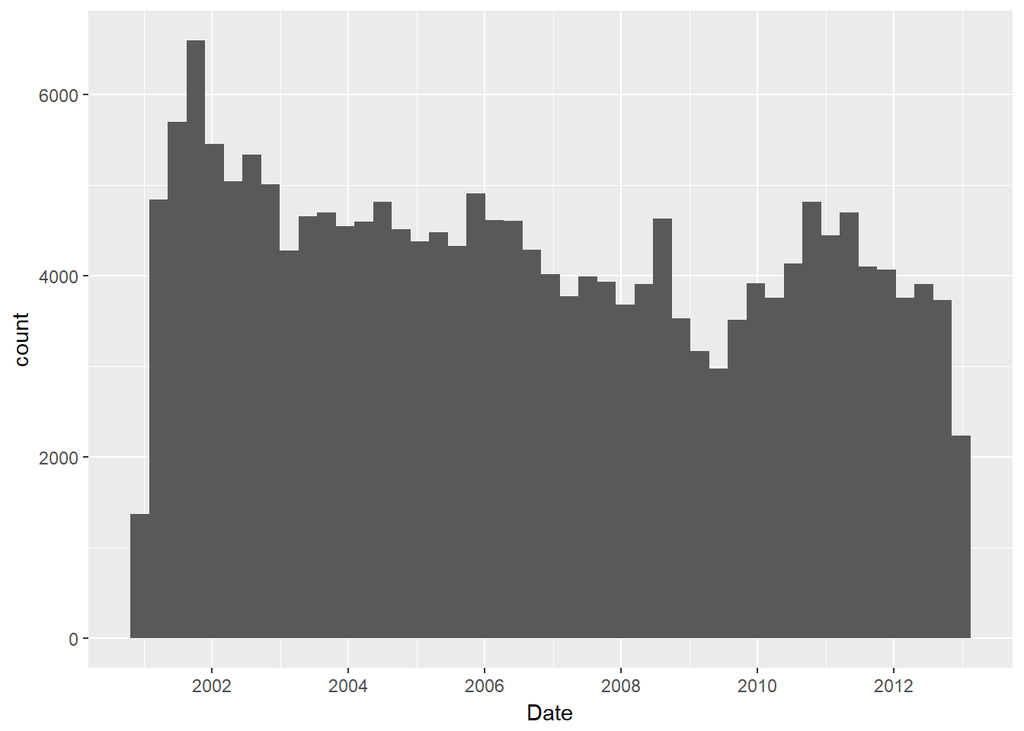

```r
ggplot(mvt, aes(x=Date)) +
  geom_histogram(binwidth = 100)
```

Now, let’s see how arrests have changed over time.

Does it look like there were more crimes for which arrests were made in the first half of the time period or the second half of the time period? (Note that the time period is from 2001 to 2012, so the middle of the time period is the beginning of 2007.)

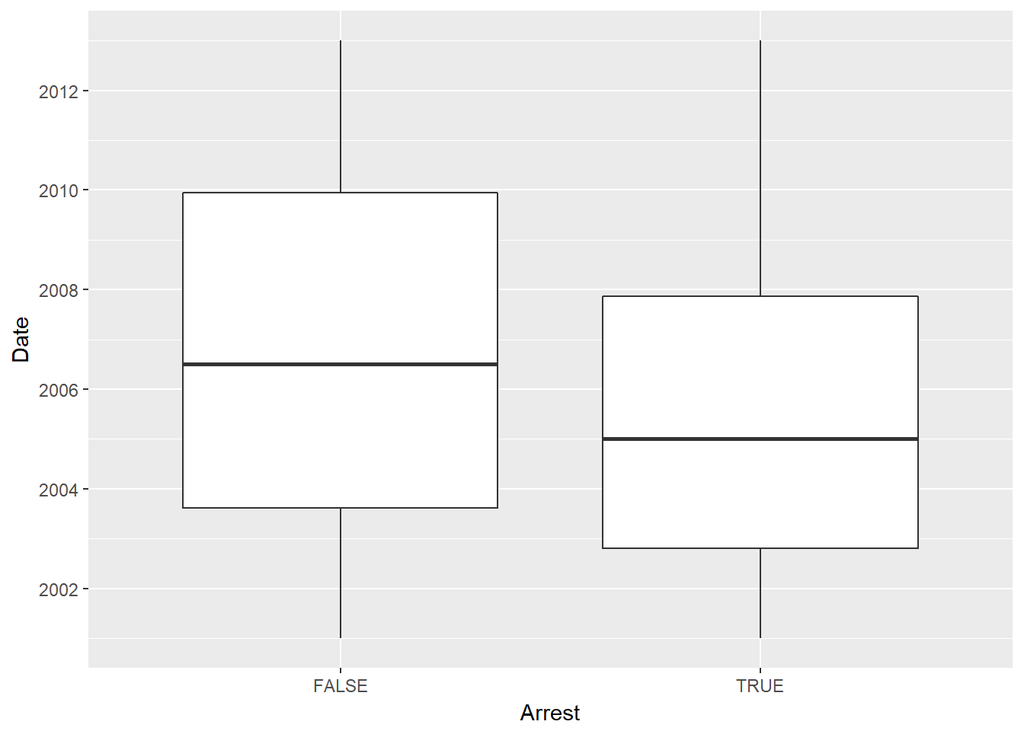

```r
  ggplot(mvt, aes(x = Arrest, y = Date)) +
    geom_boxplot()
```

## Popular Locations

For what proportion of motor vehicle thefts in 2001 was an arrest made?

```r
  mvt %>% filter(Year == 2001) %>%
    group_by(Arrest, Year) %>%
    summarise(n = n()) %>%
    ungroup() %>%
    mutate(freq = n/sum(n))
```

```
## # A tibble: 2 x 4
##   Arrest  Year     n  freq
##   <lgl>  <int> <int> <dbl>
## 1 F       2001 18517 0.896
## 2 T       2001  2152 0.104
```

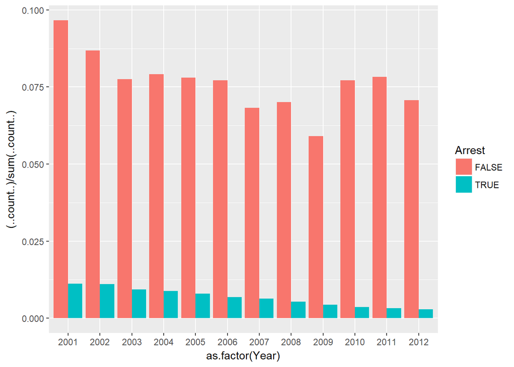

```r
ggplot(mvt, aes(x=as.factor(Year))) +
  geom_bar(aes(fill=Arrest,  y = (..count..)/sum(..count..)), position="dodge")
```

For what proportion of motor vehicle thefts in 2007 was an arrest made?

```r
   mvt %>% filter(Year == 2007) %>%
    group_by(Arrest, Year) %>%
    summarise(n = n()) %>%
    ungroup() %>%
    mutate(freq = n/sum(n))
```

```
## # A tibble: 2 x 4
##   Arrest  Year     n   freq
##   <lgl>  <int> <int>  <dbl>
## 1 F       2007 13068 0.915
## 2 T       2007  1212 0.0849
```

For what proportion of motor vehicle thefts in 2012 was an arrest made?

```r
    mvt %>% filter(Year == 2012) %>%
    group_by(Arrest, Year) %>%
    summarise(n = n()) %>%
    ungroup() %>%
    mutate(freq = n/sum(n))
```

```
## # A tibble: 2 x 4
##   Arrest  Year     n   freq
##   <lgl>  <int> <int>  <dbl>
## 1 F       2012 13542 0.961
## 2 T       2012   550 0.0390
```

Which locations are the top five locations for motor vehicle thefts, excluding the “Other” category?

```r
  mvt %>% group_by(LocationDescription) %>%
          summarise(n = n()) %>%
          top_n(6, n) %>%
          arrange(desc(n))
```

```
## # A tibble: 6 x 2
##   LocationDescription                 n
##   <fct>                           <int>
## 1 STREET                         156564
## 2 PARKING LOT/GARAGE(NON.RESID.)  14852
## 3 OTHER                            4573
## 4 ALLEY                            2308
## 5 GAS STATION                      2111
## 6 DRIVEWAY - RESIDENTIAL           1675
```

```r
Top5Locations <-  mvt %>%
          group_by(LocationDescription) %>%
          filter(LocationDescription != "OTHER") %>%
          summarise(n = n()) %>%
          top_n(5, n) %>%
          select(LocationDescription)

Top5 <- mvt %>%
        filter(LocationDescription %in% Top5Locations$LocationDescription)
Top5$LocationDescription <- factor(Top5Locations$LocationDescription)
```

```r
Top5 %>% group_by( Arrest, LocationDescription) %>%
         summarise(n = n()) %>%
         ungroup() %>%
         mutate(freq = n/sum(n)) %>%
         arrange(desc(freq))
```

```
## # A tibble: 10 x 4
##    Arrest LocationDescription                n   freq
##    <lgl>  <fct>                          <int>  <dbl>
##  1 F      STREET                         32745 0.184
##  2 F      ALLEY                          32744 0.184
##  3 F      PARKING LOT/GARAGE(NON.RESID.) 32731 0.184
##  4 F      GAS STATION                    32651 0.184
##  5 F      DRIVEWAY - RESIDENTIAL         32621 0.184
##  6 T      DRIVEWAY - RESIDENTIAL          2881 0.0162
##  7 T      GAS STATION                     2851 0.0161
##  8 T      PARKING LOT/GARAGE(NON.RESID.)  2771 0.0156
##  9 T      ALLEY                           2758 0.0155
## 10 T      STREET                          2757 0.0155
```

On which day of the week do the most motor vehicle thefts at gas stations happen?

```r
  Top5 %>% filter(LocationDescription=="GAS STATION") %>%
         group_by( Weekday) %>%
         summarise(n = n()) %>%
         arrange(desc(n))
```

```
## # A tibble: 7 x 2
##   Weekday       n
##   <chr>     <int>
## 1 Friday     5422
## 2 Monday     5078
## 3 Wednesday  5059
## 4 Thursday   5042
## 5 Saturday   5041
## 6 Tuesday    4957
## 7 Sunday     4903
```

On which day of the week do the fewest motor vehicle thefts in residential driveways happen?

```r
    Top5 %>% filter(LocationDescription=="DRIVEWAY - RESIDENTIAL") %>%
         group_by( Weekday) %>%
         summarise(n = n()) %>%
         arrange(desc(n))
```

```
## # A tibble: 7 x 2
##   Weekday       n
##   <chr>     <int>
## 1 Friday     5427
## 2 Wednesday  5061
## 3 Monday     5056
## 4 Saturday   5044
## 5 Thursday   5042
## 6 Tuesday    4962
## 7 Sunday     4910
```